# Project: Investigate Medical Appointment NO-SHOWS

- Introduction
- Data Wrangling
- Exploratory Data Analysis
- Conclusions

## Introduction

> This Medical Appointment NO-SHOWS dataset collects information from 100k medical appointments in Brazil and is focused on the question of whether or not patients show up for their appointment. A number of characteristics about the patient are included in each row.

> ```
> 1. ‘No-Show’ tells us if the patient show up their appointment or not. It says ‘No’ if the patient showed up to their appointment, and ‘Yes’ if they did not show up
> 2. ‘ScheduledDay’ tells us on what day the patient set up their appointment.
> 3. ‘Neighborhood’ indicates the location of the hospital.
> 4. ‘Scholarship’ indicates whether or not the patient is enrolled in Brasilian welfare program Bolsa Família.
> 5. ‘SMS_received’ indicates whether 1 or more messages is sent to the patient
> ```

> This dataset will be investigated to answer the following research questions:

> ```
> 1. What proportion of patients showed up for their appointments, and what proportion  did not?
> 2. What is the age distribution of the patients
> 3. What proportion of the patients received SMS?
> 4. Do people that receive SMS show up for their appointments?
> 5. What proportion of the patients are on Scholarship?
> 6. Do patients with scholarship show up for their appointments?
> ```

```python
#import packages
import pandas as pd
import numpy as np
import matplotlib.pyplot as plt

%matplotlib inline
```

## Data Wrangling

> **Tip**: In this section of the report, you will load in the data, check for cleanliness, and then trim and clean your dataset for analysis. Make sure that you document your steps carefully and justify your cleaning decisions.

### General Properties

```python
# Load data and print out a few lines.
data=pd.read_csv("noshowappointments.csv")
data.head(5)
```

|  | PatientId | AppointmentID | Gender | ScheduledDay | AppointmentDay | Age | Neighbourhood | Scholarship | Hipertension | Diabetes | Alcoholism | Handcap | SMS_received | No-show |
| --- | --- | --- | --- | --- | --- | --- | --- | --- | --- | --- | --- | --- | --- | --- |
| 0 | 2.987250e+13 | 5642903 | F | 2016-04-29T18:38:08Z | 2016-04-29T00:00:00Z | 62 | JARDIM DA PENHA | 0 | 1 | 0 | 0 | 0 | 0 | No |
| 1 | 5.589978e+14 | 5642503 | M | 2016-04-29T16:08:27Z | 2016-04-29T00:00:00Z | 56 | JARDIM DA PENHA | 0 | 0 | 0 | 0 | 0 | 0 | No |
| 2 | 4.262962e+12 | 5642549 | F | 2016-04-29T16:19:04Z | 2016-04-29T00:00:00Z | 62 | MATA DA PRAIA | 0 | 0 | 0 | 0 | 0 | 0 | No |
| 3 | 8.679512e+11 | 5642828 | F | 2016-04-29T17:29:31Z | 2016-04-29T00:00:00Z | 8 | PONTAL DE CAMBURI | 0 | 0 | 0 | 0 | 0 | 0 | No |
| 4 | 8.841186e+12 | 5642494 | F | 2016-04-29T16:07:23Z | 2016-04-29T00:00:00Z | 56 | JARDIM DA PENHA | 0 | 1 | 1 | 0 | 0 | 0 | No |

```python
#structure of the data
data.shape
```

```
(110527, 14)
```

```python
#inspect data types and look for instances of missing or possibly errant data.
data.info()
```

```
<class 'pandas.core.frame.DataFrame'>
RangeIndex: 110527 entries, 0 to 110526
Data columns (total 14 columns):
PatientId         110527 non-null float64
AppointmentID     110527 non-null int64
Gender            110527 non-null object
ScheduledDay      110527 non-null object
AppointmentDay    110527 non-null object
Age               110527 non-null int64
Neighbourhood     110527 non-null object
Scholarship       110527 non-null int64
Hipertension      110527 non-null int64
Diabetes          110527 non-null int64
Alcoholism        110527 non-null int64
Handcap           110527 non-null int64
SMS_received      110527 non-null int64
No-show           110527 non-null object
dtypes: float64(1), int64(8), object(5)
memory usage: 11.8+ MB
```

> **Tip**: You should *not* perform too many operations in each cell. Create cells freely to explore your data. One option that you can take with this project is to do a lot of explorations in an initial notebook. These don't have to be organized, but make sure you use enough comments to understand the purpose of each code cell. Then, after you're done with your analysis, create a duplicate notebook where you will trim the excess and organize your steps so that you have a flowing, cohesive report.

> **Tip**: Make sure that you keep your reader informed on the steps that you are taking in your investigation. Follow every code cell, or every set of related code cells, with a markdown cell to describe to the reader what was found in the preceding cell(s). Try to make it so that the reader can then understand what they will be seeing in the following cell(s).

```python
data.rename(columns={"Hipertension":"Hypertension"})
data.columns
```

```
Index(['PatientId', 'AppointmentID', 'Gender', 'ScheduledDay',
       'AppointmentDay', 'Age', 'Neighbourhood', 'Scholarship', 'Hipertension',
       'Diabetes', 'Alcoholism', 'Handcap', 'SMS_received', 'No-show'],
      dtype='object')
```

### Change the data type of columns ScheduleDay, AppointmentDay, and PatientId

```python
#change the data type of columns ScheduleDay, AppointmentDay, and PatientId to appropiate types
data["ScheduledDay"]=pd.to_datetime(data["ScheduledDay"])
data["AppointmentDay"]=pd.to_datetime(data["AppointmentDay"])
data.PatientId=data.PatientId.astype("int64")
data.head(5)
```

|  | PatientId | AppointmentID | Gender | ScheduledDay | AppointmentDay | Age | Neighbourhood | Scholarship | Hipertension | Diabetes | Alcoholism | Handcap | SMS_received | No-show |
| --- | --- | --- | --- | --- | --- | --- | --- | --- | --- | --- | --- | --- | --- | --- |
| 0 | 29872499824296 | 5642903 | F | 2016-04-29 18:38:08 | 2016-04-29 | 62 | JARDIM DA PENHA | 0 | 1 | 0 | 0 | 0 | 0 | No |
| 1 | 558997776694438 | 5642503 | M | 2016-04-29 16:08:27 | 2016-04-29 | 56 | JARDIM DA PENHA | 0 | 0 | 0 | 0 | 0 | 0 | No |
| 2 | 4262962299951 | 5642549 | F | 2016-04-29 16:19:04 | 2016-04-29 | 62 | MATA DA PRAIA | 0 | 0 | 0 | 0 | 0 | 0 | No |
| 3 | 867951213174 | 5642828 | F | 2016-04-29 17:29:31 | 2016-04-29 | 8 | PONTAL DE CAMBURI | 0 | 0 | 0 | 0 | 0 | 0 | No |
| 4 | 8841186448183 | 5642494 | F | 2016-04-29 16:07:23 | 2016-04-29 | 56 | JARDIM DA PENHA | 0 | 1 | 1 | 0 | 0 | 0 | No |

```python
#check for changes
data.info()
```

```
<class 'pandas.core.frame.DataFrame'>
RangeIndex: 110527 entries, 0 to 110526
Data columns (total 14 columns):
PatientId         110527 non-null int64
AppointmentID     110527 non-null int64
Gender            110527 non-null object
ScheduledDay      110527 non-null datetime64[ns]
AppointmentDay    110527 non-null datetime64[ns]
Age               110527 non-null int64
Neighbourhood     110527 non-null object
Scholarship       110527 non-null int64
Hipertension      110527 non-null int64
Diabetes          110527 non-null int64
Alcoholism        110527 non-null int64
Handcap           110527 non-null int64
SMS_received      110527 non-null int64
No-show           110527 non-null object
dtypes: datetime64[ns](2), int64(9), object(3)
memory usage: 11.8+ MB
```

```python
#check for data statistics
data.describe()
```

|  | PatientId | AppointmentID | Age | Scholarship | Hipertension | Diabetes | Alcoholism | Handcap | SMS_received |
| --- | --- | --- | --- | --- | --- | --- | --- | --- | --- |
| count | 1.105270e+05 | 1.105270e+05 | 110527.000000 | 110527.000000 | 110527.000000 | 110527.000000 | 110527.000000 | 110527.000000 | 110527.000000 |
| mean | 1.474963e+14 | 5.675305e+06 | 37.088874 | 0.098266 | 0.197246 | 0.071865 | 0.030400 | 0.022248 | 0.321026 |
| std | 2.560949e+14 | 7.129575e+04 | 23.110205 | 0.297675 | 0.397921 | 0.258265 | 0.171686 | 0.161543 | 0.466873 |
| min | 3.921700e+04 | 5.030230e+06 | -1.000000 | 0.000000 | 0.000000 | 0.000000 | 0.000000 | 0.000000 | 0.000000 |
| 25% | 4.172614e+12 | 5.640286e+06 | 18.000000 | 0.000000 | 0.000000 | 0.000000 | 0.000000 | 0.000000 | 0.000000 |
| 50% | 3.173184e+13 | 5.680573e+06 | 37.000000 | 0.000000 | 0.000000 | 0.000000 | 0.000000 | 0.000000 | 0.000000 |
| 75% | 9.439172e+13 | 5.725524e+06 | 55.000000 | 0.000000 | 0.000000 | 0.000000 | 0.000000 | 0.000000 | 1.000000 |
| max | 9.999816e+14 | 5.790484e+06 | 115.000000 | 1.000000 | 1.000000 | 1.000000 | 1.000000 | 4.000000 | 1.000000 |

```python
data.describe(include="O")
```

|  | Gender | Neighbourhood | No-show |
| --- | --- | --- | --- |
| count | 110527 | 110527 | 110527 |
| unique | 2 | 81 | 2 |
| top | F | JARDIM CAMBURI | No |
| freq | 71840 | 7717 | 88208 |

## Exploratory Data Analysis

> **Tip**: Now that you've trimmed and cleaned your data, you're ready to move on to exploration. Compute statistics and create visualizations with the goal of addressing the research questions that you posed in the Introduction section. It is recommended that you be systematic with your approach. Look at one variable at a time, and then follow it up by looking at relationships between variables.

### Research Question 1: What proportion of patients showed up for their appointments, and what proportion did not?

```
Text(0.5,1,' What proportion of patients showed up for their appointments?')
```

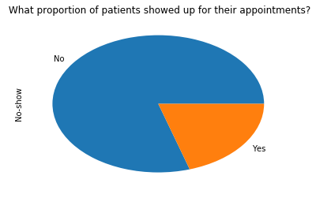

```python
#visualize the proportion of patients showed and did not show up for appointments
data["No-show"].value_counts().plot(kind="pie")
plt.title(" What proportion of patients showed up for their appointments?")
```

**Answer:** From the chart above, it appears that approximately 80% of the patients show up for thier appointments, while the remaining 20% do not

### Research Question 2: What is the age distribution of the patients?

```python
#a function to add title, xlabel, and ylabel to the plots
def describe_chart(title,xlabel,ylabel):
    plt.title(title)
    plt.xlabel(xlabel)
    plt.ylabel(ylabel)
```

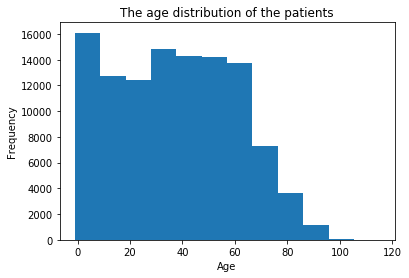

```python
#see the distribution of age
plt.hist(data["Age"], bins=12)
describe_chart("The age distribution of the patients","Age","Frequency")
```

### Research Question 3: What proportion of the patients received SMS?

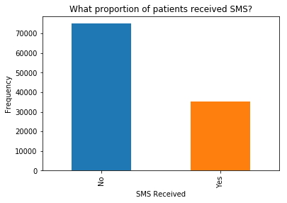

```python
#see the proportion of the patients received SMS
data["SMS_received"].value_counts().plot(kind="bar")
plt.xticks([0,1],["No","Yes"])
describe_chart("What proportion of patients received SMS?","SMS Received","Frequency")
```

**Answer:** From the chart above, it appears that less than a 1/3 of the patients received SMS

### Research Question 4: Do people that receive SMS show up for their appointments?

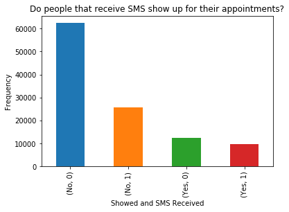

```python
# see the number of people that showed for their appointments after receiving SMS
data.groupby(["No-show"])["SMS_received"].value_counts().plot(kind="bar")
describe_chart("Do people that receive SMS show up for their appointments?","Showed and SMS Received","Frequency")
```

**Answer:** In the chart above, the orange bar represents those that received SMS and showed, while the red bar represents those that received SMS and did not show. It appears that more than 2/3 of the patients that received SMS came for their appointments.

### Research Question 5: What proportion of the patients are on Scholarship?

```
Text(0.5,1,'What proportion of the patients are on Scholarship?')
```

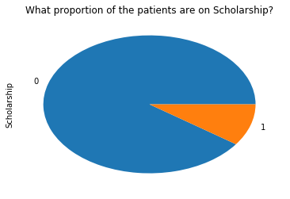

```python
#see the proportion of the patients are on Scholarship
data["Scholarship"].value_counts().plot(kind="pie")
plt.title("What proportion of the patients are on Scholarship?")
```

**Answer:** From the chart above, it appears that approximately 10% of the patients are on Scholarship

### Research Question 6: Do patients with scholarship show up for their appointments?

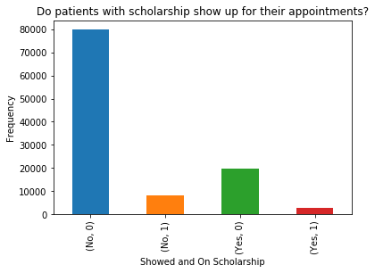

```python
# see the number of people that under scholarship that showed for their appointments
data.groupby(["No-show"])["Scholarship"].value_counts().plot(kind="bar")
describe_chart("Do patients with scholarship show up for their appointments?","Showed and On Scholarship","Frequency")
```

```python
from subprocess import call
call(['python', '-m', 'nbconvert', 'Investigate_a_Dataset.ipynb'])
```

```
0
```